**2023年度 東京成徳大学 特別講座 資料**  
**東京工科大学コンピュータサイエンス学部**  
**福西広晃**

Pythonの基礎

# 比較演算子

- 等しい(==)、〇〇以上(>=)、〇〇未満(<)などの左辺と右辺の比較に使う演算記号を、`比較演算子`と言う
- 出力は`True`（真）または`False`（偽）
- 左辺の変数に右辺の値を代入する場合は`=`であったが、左辺と右辺の値を比較する場合は`==`を使うことに注意

[output not shown]

## 数値の比較

```python
num1 = 10

# 等しい
print("判定1: ", num1 == 10)

# 等しくない
print("判定2: ", num1 != 10)

# 大きい
print("判定3: ", num1 > 10)

# 小さい
print("判定4: ", num1 < 10)

# 以上
print("判定5: ", num1 >= 10)

# 以下
print("判定6: ", num1 <= 10)
```

```
判定1:  True
判定2:  False
判定3:  False
判定4:  False
判定5:  True
判定6:  True
```

## 練習

- 円の面積が100cm<sup>2</sup>を超えるかを判定計算するプログラムを作成する。半径を表す変数を`r`、面積を表す変数を`area`とする。半径が`5.5`cmの場合の面積を計算し、100cm<sup>2</sup>を超えるかの判定結果を`True`または`False`で出力してみよう。
- 半径を変えて`7.5`cmの場合を試してみよう

解答例

```python
r = 5.5         # 半径
area = r*r*3.14 # 円の面積
print("判定:", area > 100)
```

```
判定: False
```

# 論理演算子

- 2つ以上の比較条件の組み合わせを判定する場合に使う
- 出力は`True`（真）または`False`（偽）

| 論理演算子 | and | 両者を満たす |
| --- | --- | --- |
|  | or | どちらか片方を満たす |
|  | not | 満たさない |

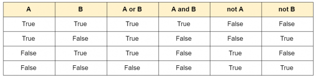

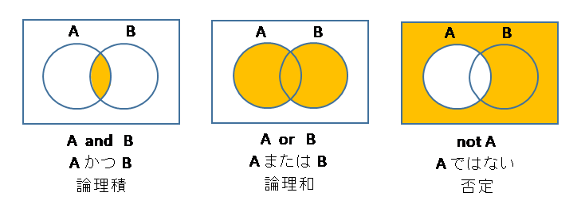

## ２つの比較条件の組み合わせ

```python
num1 = 10
num2 = 20

# 条件1と条件2の両方を満たすか
print("判定1: ", num1 >= 10 and num2 <= 10)

# 条件1と条件2のどちらかを満たすか
print("判定2: ", num1 >= 10 or num2 <= 10)

# 条件を満たさないか
print("判定3: ", not num1 >= 10)

# 条件を満たさないか
print("判定4: ", not num2 <= 10)
```

```
判定1:  False
判定2:  True
判定3:  False
判定4:  True
```

## ３つの比較条件の組み合わせ

```python
num1 = 10
num2 = 20
num3 = 30

# 条件1と条件2と条件3を同時に満たすか
print("判定1: ", num1 >= 10 and num2 <= 10 and num3 == 10)

# 条件1と条件2と条件3のいずれかを満たすか
print("判定2: ", num1 >= 10 or num2 <= 10 or num3 == 10)
```

```
判定1:  False
判定2:  True
```

## 練習

- 直方体の体積が1000cm<sup>3</sup>以上1200cm<sup>3</sup>以下かを判定するプログラムを作成する。縦の長さを表す変数を`a`、横の長さを表す変数を`b`、高さを表す変数を`c`、体積を表す変数を`volume`とする。縦の長さが`8.5`、横の長さが`9.2`、高さが`11.1`の場合の体積を計算し、1000cm<sup>3</sup>以上1200cm<sup>3</sup>以下かの判定結果を`True`または`False`で出力してみよう。円周率は3.14とする。
- 縦の長さを`9.8`に変えた場合を試してみよう

解答例

```python
a = 8.5
b = 9.2
c = 11.1
volume = a * b * c

# 1000以上と1200未満の条件を論理演算子で組み合わせる
print(volume >= 1000 and volume <= 1200)

#または以下の書き方でもOK
# print(1000 < volume < 1200)
```

```
False
```

# 制御構文

- プログラムに高度な機能（電卓以上）を持たせるためには制御構文が必要
- 制御構文とは、プログラムの実行順序を制御するためにもの
- プログラムは、`順次`，`選択（分岐）`，`反復（繰り返し、ループ)`の3つ制御構文の組み合わせである
- この3つによって、あらゆる実行順序が記述できる

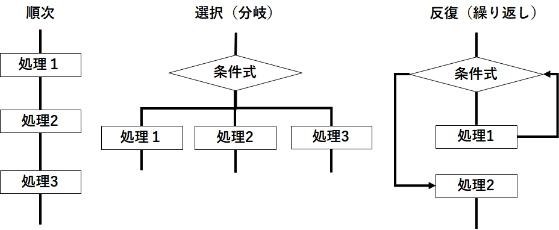

# 選択（分岐）

## 条件文（if文）

- 選択（分岐）には`条件文（if文）`を用いる
- if文を用いることで、**「もし〇〇だったら、処理A。そうでなく△△だったら、処理B。」**のように、条件によって処理を変更できる
- **1つの条件を判定する場合**

  ```
  if 条件式1:
    条件式1がTrue(真)ならば、ここに記述された処理を行う
  ```

  条件式の後に`:`(コロン)が付く（**付け忘れしやすいので注意**）
- **複数の条件を判定する場合**

  ```
  if 条件式1:
    条件式1がTrue(真)ならば、ここに記述された処理を行う
  elif 条件式2:
    条件式1がFalse(偽)で、条件式2がTrue(真)ならば、ここに記述された処理を行う
  else:
    全ての条件式がFalse(偽)ならば、ここに記述された処理を行う
  ```

  ifの条件式が満たされていなければ、elifの条件式が上から順番に判定される  
  これらの条件式がすべて満たされていなければ、else内の処理が実行される

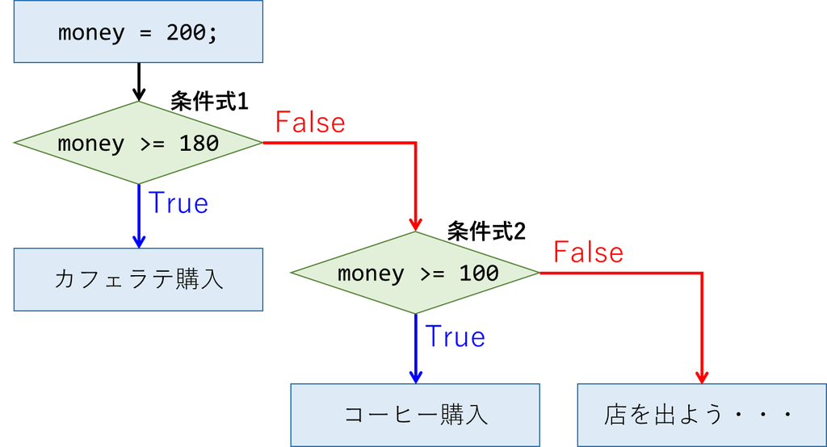

**[注意事項]**

- if文の処理を記述する際は`空白（半角スペース）を入れて字下げ`しなければならない（「`インデントを揃える`」という）。通常、半角スペース4つ
- 毎回半角スペースのキーを4回打つのは面倒なので、`Tab`キーを押せば自動的に調整してくれる

## 条件が1個

**変数numが100未満なら「AAA」と出力するプログラム**

```python
num = 50
if num < 100:
    print("AAA")
```

```
AAA
```

## 条件が2個

変数numが100未満なら「AAA」、それ以外は「BBB」と出力するプログラム**

```python
num = 101
if num < 100:
    print("AAA")
else:
    print("BBB")
```

```
BBB
```

## 条件が3個

**変数numが100未満なら「AAA」、100以上200未満なら「BBB」、それ以外は「CCC」と出力するプログラム**

```python
num = 150
if num < 100:
    print("AAA")
elif num < 200:
    print("BBB")
else:
    print("CCC")
```

```
BBB
```

## 条件が4個

**変数numが100未満なら「AAA」、100以上200未満なら「BBB」、200以上300未満なら「CCC」、それ以外は「DDD」と出力するプログラム**

```python
num = 150
if num < 100:
    print("AAA")
elif num < 200:
    print("BBB")
elif num < 300:
    print("CCC")
else:
    print("DDD")
```

```
BBB
```

## 論理演算子を用いたif文

**トランプカードがダイアで10以上ならポイントが10点、それ以外なら2点加算されるプログラムを作成する。初期値として100ポイントを持つ**

```python
points = 100 # ポイント、初期値

num = 10          # トランプの番号
mark = "diamond"  # トランプのマーク

if num >=10 and mark == "diamond":
    points = points + 10
else:
    points = points + 2
print(points)
```

```
110
```

## 練習

(2) 国語と算数のテストのどちらも60点以上なら「合格」、どちらかが90点以上なら「合格」、それ以外は「不合格」と表示するプログラムを作成しよう。国語の点数を表す変数を`kokugo`として40を代入、算数の点数を表す変数を`sansuu`として80を代入するものとする。

解答例

```python
# (1)
score = 80

if score > 60:
    print("合格")
else:
    print("不合格")
```

```
合格
```

```python
# (2)
kokugo = 40
sansuu = 80

if kokugo >= 60 and sansuu >=60:
    print("合格")
elif kokugo >=90 or sansuu >=90:
    print("合格")
else:
    print("不合格")
```

```
不合格
```